# Capstone project

Jordan Prahl

04/27/2021

## Introduction

For my capstone project, I have chosen to generate a heatmap of my re-analyzed data. I am comparing RNAseq data from my rs356182-lesion clones to several wildtype controls (both differentiated and undifferentiated). Previously, I was using results generated by Steve Pierce to generate figures and do comparisons, but we decided some of the samples didn’t make sense to include anymore. I chose to re-perform the analysis from scratch using only the relevant fastq sample files. Samples needed to be unpacked, have the adapters trimmed off, be aligned to a reference genome, and output a reads/gene count file. This was done in several steps below. The presence of both single end and paired-end data made the analysis more complicated.

## Processing data on the HPC

The Genomics core provided us with fastq files from our RNAseq experiments. For this analysis, I am pulling from three different experiments (Single-end read LUHMES differentiated vs undifferentiated, paired-end read LUHMES differentiated vs undifferentiated, and my lesion clones). The fastq files were collected into one directory in my folder on the server.For the sake of brevity, I have removed all of the extra stuff I would normally include in code to echo job details Or provide simple instructions for myself. First I index the reference genome. I included the code for retrieving the genome if necessary.

```bash
#PBS -l nodes=1:ppn=4
#PBS -l mem=24gb
#PBS -l walltime=24:00:00
#PBS -N GRCh38_index
#PBS -M jordan.prahl@vai.org
#PBS -m abe
#PBS -V

#--------- PBS VARIABLES
#- #PBS -l nodes=1:ppn=1 == ppn=1 means using 1 core per job
#- #PBS -l mem=6gb == 6gb of ram per 1 core (if ppn=4 change mem=24gb)
#- #PBS -l walltime=24:00:00 == 24 hours max runtime
#- #PBS -q shortq == choose queue shortq < 72hrs, longq > 72hrs (qstat -q)
#- #PBS -N Job_Name_Here == job name sepcific to your script
#- #PBS -t 1-20 == 20 samples and 20 jobs to submit
#- #PBS -j oe == job standard error and output files merged
#- #PBS -M First_Name.LastName@vai.org == vai email
#- #PBS -m abe == a = email if aborted, b = email when started, e = email when finished
#- #PBS -V == head node environment passed to job node environment

#--------- Gencode
#- Human Gencode_GRCh38_p10
## https://www.gencodegenes.org/human/
## wget ftp://ftp.ebi.ac.uk/pub/databases/gencode/Gencode_human/release_34/gencode.v34.primary_assembly.annotation.gff3.gz
## wget ftp://ftp.ebi.ac.uk/pub/databases/gencode/Gencode_human/release_34/GRCh38.primary_assembly.genome.fa.gz
## gunzip GRCh38.primary_assembly.genome.fa.gz
## gunzip gencode.v34.primary_assembly.annotation.gtf.gz

#--------- Number of CORES (change PBS ppn)
numcores=4

# Load in the STAR module I use to index the genome
module initadd bbc/STAR/STAR-2.7.3a

# Map out my directories
projectDir=~/coetzee-primary/Prahl/Bioinformatics_Resources
inDir=${projectDir}/genomes
fasta=${inDir}/GRCh38.primary_assembly.genome.fa
gtf=${inDir}/gencode.v34.primary_assembly.annotation.gtf
outDir=${inDir}/STAR_index
mkdir -p ${outDir}

# Run the STAR function
STAR --runThreadN ${numcores} \
                --runMode genomeGenerate \
                --genomeDir ${outDir} \
                --genomeFastaFiles ${fasta} \
                --sjdbGTFfile ${gtf} \
                --sjdbOverhang 75
```

Next, I use CUTADAPT to remove the adapters from the reads in each file.

```bash
#PBS -l nodes=1:ppn=28
#PBS -l walltime=24:00:00
#PBS -N CUTADAPT_Prahl
#PBS -M jordan.prahl@vai.org
#PBS -V
#PBS -t 1-42
#PBS -m a


#--------- PBS VARIABLES
#- #PBS -l nodes=1:ppn=1 == ppn=1 means using 1 core per job
#- #PBS -l mem=6gb == 6gb of ram per 1 core (if ppn=4 change mem=24gb)
#- #PBS -l walltime=24:00:00 == 24 hours max runtime
#- #PBS -q shortq == choose queue shortq < 72hrs, longq > 72hrs (qstat -q)
#- #PBS -N Job_Name_Here == job name sepcific to your script
#- #PBS -t 1-42 == 42 samples and 42 jobs to submit
#- #PBS -j oe == job standard error and output files merged
#- #PBS -M First_Name.LastName@vai.org == vai email
#- #PBS -m abe == a = email if aborted, b = email when started, e = email when finished
#- #PBS -V == head node environment passed to job node environment


module add bbc/cutadapt/cutadapt-2.10
module add bbc/fastqc/fastqc-0.11.8

# First I map out where my data is going. The raw fastq.gz files are in the project directory (proDir).
PROJECT=COEG_20200225_RNA
baseDir=~/coetzee-primary/Prahl/Bioinformatics_Resources
proDir=${baseDir}/Projects/${PROJECT}
genDir=${baseDir}/genomes
trimDir=${proDir}/RNA_seq
bamDir=${trimDir}/STAR
mkdir -p ${bamDir}

# Create a list of file names to use to call you data.
cd ${proDir}
ls > sampleNames.sh # Creates the list of names
sed 's/RNA_seq//' sampleNames.sh   # Removes the RNA_seq directory from the list of files
sed 's/_RNA_seq_R1.fastq.gz//' sampleNames.sh   # Removes the _R1 suffix from each name in the list
sed 's/_RNA_seq_R2.fastq.gz//' sampleNames.sh   # Removes the _R2 suffix from each name in the list
sort -u sampleNames.sh   # Sort your list of sample names; always a good idea
sampleFile=${proDir}/sampleNames.sh


sampleName=`head -n ${PBS_ARRAYID} ${sampleFile} | tail -n1` # Create an array variable which calls each file from our list of sample names.

gunzip *.gz # Unzip everything in the project directory
inFile1=${proDir}/${sampleName}_R1.fastq
inFile2=${proDir}/${sampleName}_R2.fastq # If data is single ended, then remove this line


cutadapt \
    -a AGATCGGAAGAGC -A AGATCGGAAGAGC \   # Remove second adapter in single-end data
    -o ${trimDir}/${sampleName}_R1_trim.fastq \
    -p ${trimDir}/${sampleName}_R2_trim.fastq ${inFile1} ${inFile2} \  # If data is single ended, then remove this line but leave the infile1 variable call.
    --minimum-length 1
```

Next, I align my trimmed reads to the reference genome using STAR. In this chunk I have excluded the PBS instructions which are essentially the same as used before, with more cores and a different job_ID.

```bash
CORES=28 # Determine how many cores you want to use

### Again, map out my directory paths
PROJECT=COEG_20200225_RNA
baseDir=~/coetzee-primary/Prahl/Bioinformatics_Resources
proDir=${baseDir}/Projects/${PROJECT}
genDir=${baseDir}/genomes
trimDir=${proDir}/RNA_seq2
bamDir=${trimDir}/STAR3
mkdir -p ${bamDir}

### Call the STAR module we use for the alignment
module add bbc/STAR/STAR-2.7.3a

### Make an array variable for our file names.
SAMPLEFILE=${proDir}/sampleNames.sh
SAMPLENAME=`head -n ${PBS_ARRAYID} ${SAMPLEFILE} | tail -n1`

INFILE1=${trimDir}/${SAMPLENAME}_R1_trim.fastq
INFILE2=${trimDir}/${SAMPLENAME}_R2_trim.fastq # Remove for single-end data

### Run the STAR chunk
STAR --runMode alignReads \
       --runThreadN ${CORES} \
       --genomeDir ${genDir}/STAR_index \
       --genomeLoad NoSharedMemory \
       --readFilesIn ${INFILE1} ${INFILE2}  \   # Remove INFILE2 for single-end data
       --outFileNamePrefix ${bamDir}/${SAMPLENAME}_ \
       --outReadsUnmapped None \
       --outSAMtype BAM SortedByCoordinate \
       --outFilterMismatchNoverLmax 0.1 \
       --quantMode GeneCounts \   # THis generates the readsPerGene.out.tab file I use for downstream analysis.
       --twopassMode Basic
```

If you want to use your BAM files to do further analysis, like reading into IGV, you need to index the bam files.

```bash
CORES=1

# Map out directories
PROJECT=COEG_20200225_RNA
baseDir=~/coetzee-primary/Prahl/Bioinformatics_Resources
proDir=${baseDir}/Projects/${PROJECT}
genDir=${baseDir}/genomes
trimDir=${proDir}/RNA_seq
bamDir=${trimDir}/STAR

### Create an array variable to call each file
SAMPLEFILE=${proDir}/sampleNames.sh
SAMPLENAME=`head -n ${PBS_ARRAYID} ${SAMPLEFILE} | tail -n1`


INFILE=${bamDir}/${SAMPLENAME}_Aligned.sortedByCoord.out.bam

### Load up the samtools module
module add bbc/samtools/samtools-1.9

### Simple code to index your BAM files
samtools index ${INFILE}
```

The last thing you need in order to manipulate your samples in IGV is the bigwig file.The code to generate this file is simple.

```bash
# First I map out where my data is going. The raw fastq.gz files are in the project directory (proDir).
PROJECT=COEG_20200225_RNA
baseDir=~/coetzee-primary/Prahl/Bioinformatics_Resources
proDir=${baseDir}/Projects/${PROJECT}
genDir=${baseDir}/genomes
trimDir=${proDir}/RNA_seq
bamDir=${trimDir}/STAR
mkdir -p ${bamDir}

### Create an array variable to call each file
SAMPLEFILE=${proDir}/sampleNames.sh
SAMPLENAME=`head -n ${PBS_ARRAYID} ${SAMPLEFILE} | tail -n1`

### Load up the required deeptools module
module add bbc/deeptools/deeptools-3.4.3

bamcoverage -b ${bamDir}/${SAMPLENAME}_Aligned.sortedByCoord.out.bam -o ${SAMPLENAME}.bw
```

I think you could theoretically do all of this in one big script, but I was never able to get it to run smooth all the way through (especially with single-end data mixed in with the paired-end data). Doing so would provide a clearer set of steps and abbreviate the need to repeat the directory mapping and sample name calling in each script.

## Initialization of count data

First, I must read in all of our ReadsPerCount.out.tab files and combine them into one matrix. The reads files have already been moved into the R working directory. I remove labeling artifacts pulled over from the file path, and then use an adaptation of the limma-voom processing method. Gene information is pulled from org.HS.eg.db.

```r
#if (!requireNamespace("BiocManager"))
#    install.packages("BiocManager")
# BiocManager::install(c("limma", "edgeR", "Glimma", "org.Hs.eg.db", "gplots", "RColorBrewer", "NMF", "BiasedUrn"))
# BiocManager::install("devtools")
# devtools::install_github("cmartin/ggConvexHull")
# BiocManager::install("gridExtra")
# BiocManager::install("cowplot")
# BiocManager::install('EnhancedVolcano')


library(edgeR)
library(limma)
library(Glimma)
library(gplots)
library(RColorBrewer)
library(NMF)
library(dplyr)
library(tidyverse)
library(AnnotationDbi)
library(org.Hs.eg.db)
library(reshape2)
library(ggplot2)
library(ggfortify)
library(magrittr)
library(tibble)
library(DataCombine)
library(plyr)
library(EnhancedVolcano)
library(devtools)
library(ggConvexHull)
library(gridExtra)
library(cowplot)
```

```r
ff <- list.files( path = "./readCounts/20210420", pattern = "_ReadsPerGene.out.tab$", full.names = TRUE ) # make a list of file names
counts.files <- lapply( ff, read.table, skip = 4 ) ### read files and create data frame without first 4 rows of meta-data
counts <- sapply( counts.files, function(x) x[ , 2 ] ) ### put counts for each sample into a matrix based on values in the second column (non-stranded counts)
ff <- gsub( "_ReadsPerGene.out.tab", "", ff ) ### remove "_ReadsPerGene.out.tab" from end of file names
ff <- gsub( "./readCounts/20210420", "", ff ) ### remove file path from sample names
colnames(counts) <- ff ### add column labels to count matrix (sample names)
row.names(counts) <- counts.files[[1]]$V1 ### add the ensemble ID to rows of count matrix

rownames(counts) <- gsub("\\..+","",rownames(counts)) ### Remove decimals from ENSEMBLE IDs
counts <- unique.matrix(counts) ### Remove duplicates
colnames(counts) <- gsub("/","",colnames(counts))
my_dge <- DGEList(counts, genes=rownames(counts)) ### Create a DGE list from counts

# Here we are taking gene information from the org.Hs.eg.db and applying it to our gene list in my_dge
my_dge$genes$Symbol <- mapIds(org.Hs.eg.db,
                         rownames(my_dge),
                         keytype="ENSEMBL", column="SYMBOL")
```

## Thresholding my count data

Now I have all of my count data with gene info in one object; my_dge. I am going to plot my raw counts against their cpm data to determine what the threshold for low counts should be. In general, a threshold should be chosen for a CPM corresponding to about 10 reads. In the example (https://combine-australia.github.io/RNAseq-R/06-rnaseq-day1.html), they use 0.5 cpm. For my data it looks like that will be closer to 0.115.

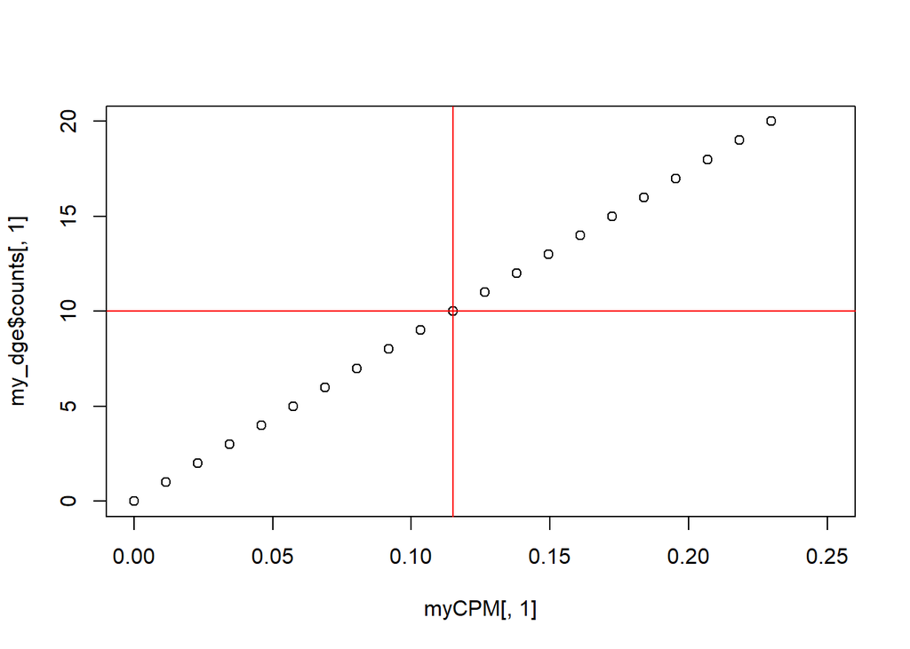

```r
myCPM <-cpm(my_dge) #Create an object transformed for counts per million

plot(myCPM[,1],my_dge$counts[,1],ylim=c(0,20),xlim=c(0,0.25))
abline(h=10, v=0.115, col="red")
```

```r
thresh <- myCPM > 0.115 # Apply my newly determined threshold to my cpm data
table(rowSums(thresh))
```

```
##
##     0     1     2     3     4     5     6     7     8     9    10    11    12
## 10632  1978  1076   690   595   475   459   391   361   469   398   388   386
##    13    14    15    16    17    18    19    20    21    22    23    24    25
##   349   340   342   365   427   757   405   375   310   299   321   367   436
##    26    27
##   637 14174
```

```r
keep <- rowSums(thresh) >= 2 # keep only those genes which are expressed in at least 2 samples (since we have replicates, anything unique to one sample is considered noise).
summary(keep)
```

```
##    Mode   FALSE    TRUE
## logical   12610   25592
```

```r
my_dge <- my_dge[keep, , keep.lib.sizes=FALSE] #We filtered out 12,610 genes not expressed in our samples
dim(my_dge) # confirmed that the TRUE values from our summary(keep) matches the number of rows (25592)
```

```
## [1] 25592    27
```

```r
#my_dge <- calcNormFactors(my_dge) ### normalize read counts

logcounts <- cpm(my_dge,log=TRUE) # Log transform the cpm data into a new object for later use. Other methods of log transformation will return error from zero-count values. This method provides a slight offset so that we don't lose data.
```

## QC the library sizes

These plots will provide some insight into the library diversity. Ideally, your library sizes will be about equal, but that’s not the case with our data due to the experiments being done in slightly different ways at different times. The diversity is evident from the barplots but shouldn’t be an issue after we correct for cpm (as seen from the normalized box/whisker plots).

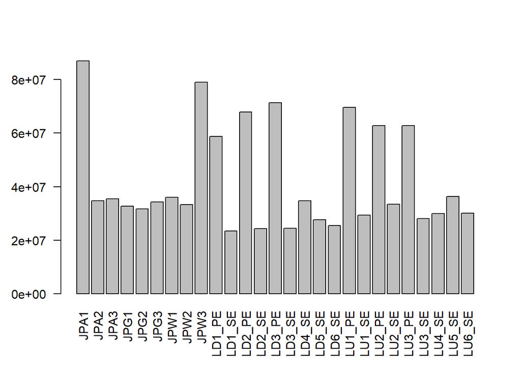

```r
barplot(my_dge$samples$lib.size,names=colnames(my_dge),las=2) # Quality control step, here we see that several of our samples were sequenced to a much greater depth. Normalizing to CPM should address any problems here.
```

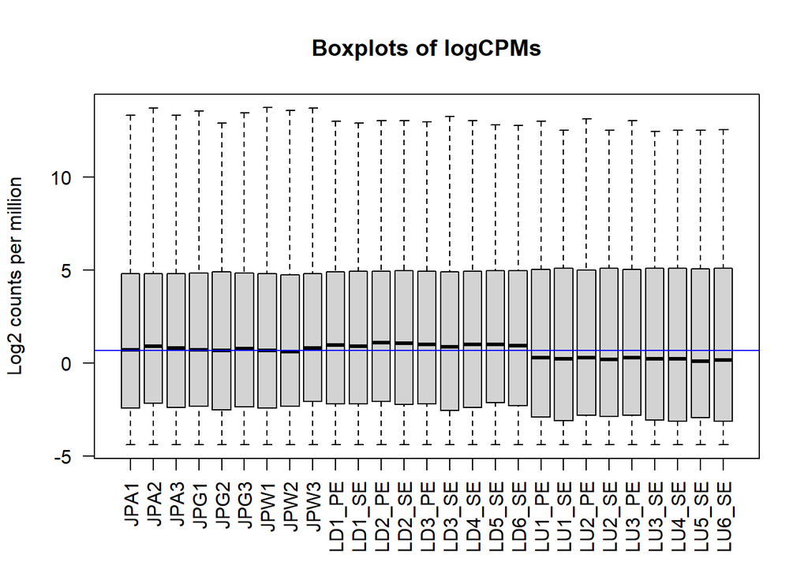

```r
# Another quality control step looking at CPM normalized read-counts. Here we see our transformation has normalized read distribution.
boxplot(logcounts, xlab="", ylab="Log2 counts per million",las=2, main="Boxplots of logCPMs")
abline(h=median(logcounts),col="blue")
```

## Principle component analysis

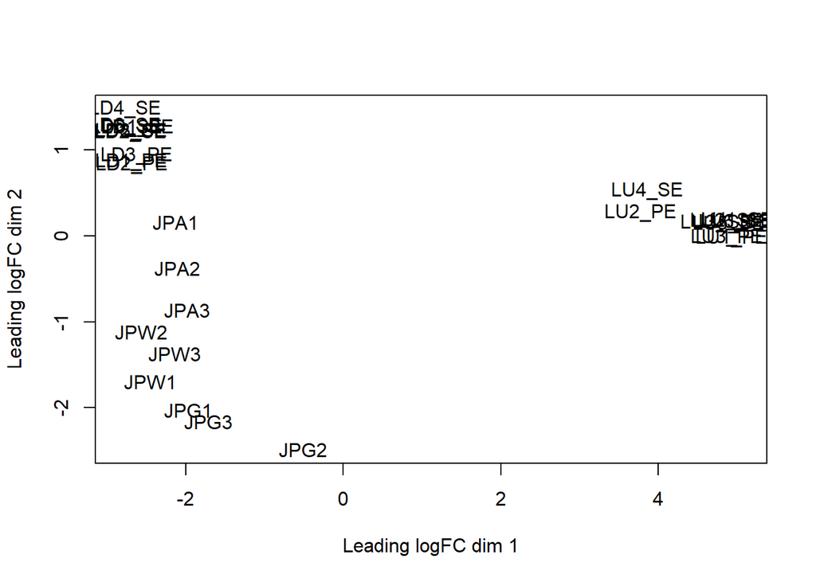

```r
plotMDS(my_dge) # This is a simple plot that provides a lot of info based on principle component analysis
```

MDS plots provides a simple visualization of the principle components accounting for variability between samples. In order to get a better idea of what makes our components different, I use a PCA plot grouped by different parameters of our data. To accomplish this in a higher throughput manner, I wrote my first simple function.

```r
#For a better look at principle components, I will use a PCA plot. I'm also adding in a bunch of extra factors to see how they stratify across PCs.
pca_data <- prcomp(t(logcounts), scale = T)

pData <- data.frame(pca_data$x)

pData$Geno <- c("A/-","A/-","A/-","G/-","G/-","G/-","A/G","A/G","A/G", rep("LD", times=9), rep("UD", times=9))
pData$ends <- c(rep("paired",times=10), "single", "paired", "single", "paired", rep("single", times=4), "paired", "single", "paired", "single", "paired", rep("single", times=4))
pData$crispr <- c(rep("exposed", times=9), rep("naive", times=18))
pData$edited <- c(rep("TRUE", times=6), rep("FALSE", times=21))
pData$investigator <- c(rep("JP", times=9), rep("TT", times=18))
pData$diff <- c(rep("diff", times=18), rep("undiff", times=9))

#write.csv2(data.frame(pData), './PCA_dataframe.csv')

var_explained <- pca_data$sdev^2/sum(pca_data$sdev^2) # Add variance to plot axis
```

Before I knew how to write functions, I wrote this caveman version of a function in which I could change the paramters in the **xydims** object which were then called in the plot code below.

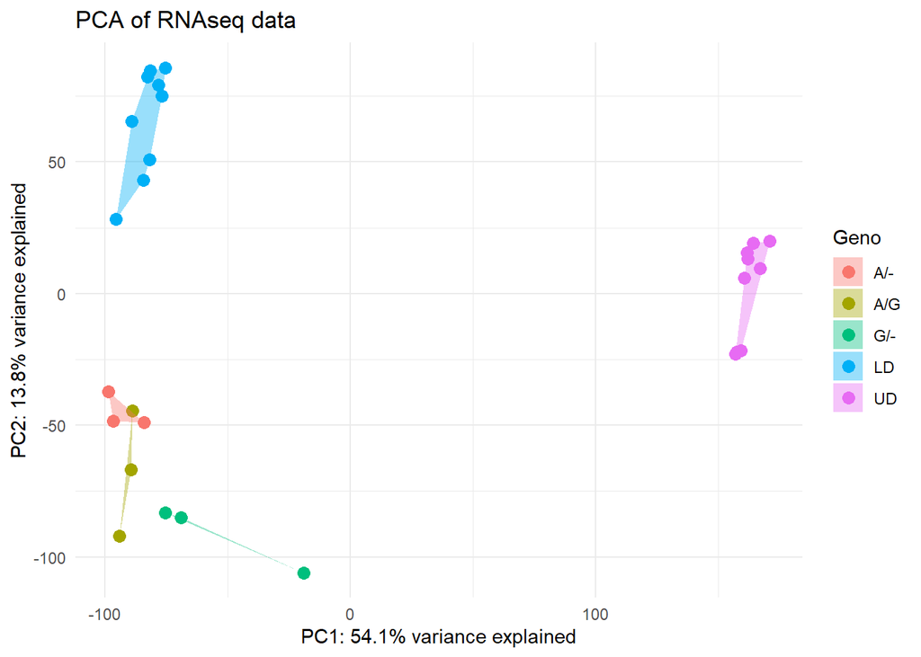

```r
{ #START PLOT HERE (ctrl + enter)
     # Choose your dimensions in the xydims vector below.
     # PCA has 33 dimensions, UMAP has 5, and TSNE only has 3 dimensions

  xydims <- c(
              "PC1",  # X-Axis
              "PC2",  # Y-axis
              "PCA"  # Dimension reduction method: UMAP, PCA, or TSNE
              )
  vvar1 <- as.numeric(substring(xydims[1],3,3))
  vvar2 <- as.numeric(substring(xydims[2],3,3))

  Geno12<- ggplot(data=pData, aes_string(x=noquote(paste0(xydims[1])),y=noquote(paste0(xydims[2])))) +
     geom_point(aes(color = Geno),size=3) +
     ggtitle("PCA of RNAseq data") +
     xlab(paste0(xydims[1], ": ", round(var_explained[vvar1]*100,1),"% variance explained")) +
     ylab(paste0(xydims[2], ": ", round(var_explained[vvar2]*100,1),"% variance explained")) +
     theme_minimal() + #theme(legend.position = "none") +
     geom_convexhull(alpha = 0.4,aes(fill = Geno))
Geno12
}
```

### Writing a figure-function

As is evident from the above code chunk, I was attempting to automate the figure making process to some degree. This way, my figures would be more uniform and generating them would be faster. The chunk was set up so you can change 3 variable strings in a vector at the top of the chunk, and the code would reference those variables to generate figures with those parameters. It wasn’t until after I made functional versions of these caveman functions that I learned how to do this properly using the function method. Now when I want to change parameters, rather than pasting the entire chunk again, it’s just one line that, making my output much more concise.

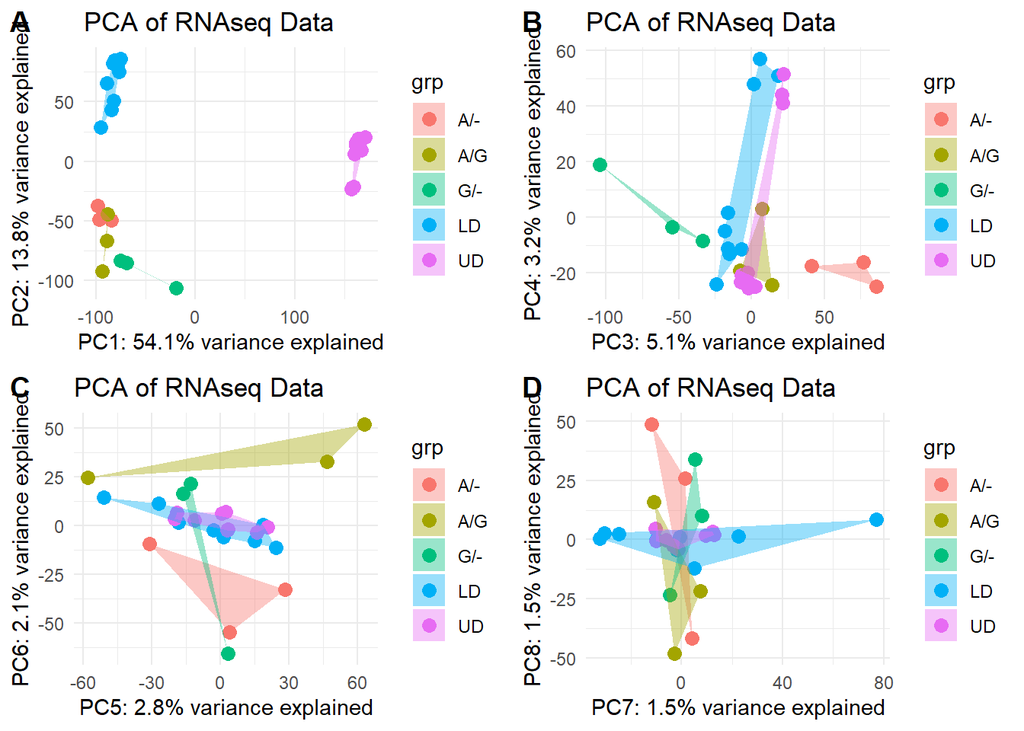

```r
pca.fig <- function(data, x_pc, y_pc, grp) {
  vvar1 <- as.numeric(substring(x_pc,3,3))
  vvar2 <- as.numeric(substring(y_pc,3,3))
  ggplot(data=data, aes_string(x=paste0(x_pc), y=paste0(y_pc))) +
    geom_point(aes(color = grp),size=3) +
    theme_minimal() +
    ggtitle("PCA of RNAseq Data") +
    xlab(paste0(x_pc, ": ", round(var_explained[vvar1]*100,1),"% variance explained")) +
    ylab(paste0(y_pc, ": ", round(var_explained[vvar2]*100,1),"% variance explained")) +
    geom_convexhull(alpha = 0.4,aes(fill = grp))
}

a <- pca.fig(pData, 'PC1','PC2', pData$Geno)
b <- pca.fig(pData, 'PC3', "PC4", pData$Geno)
c <- pca.fig(pData, 'PC5', "PC6", pData$Geno)
d <- pca.fig(pData, 'PC7', "PC8", pData$Geno)

# New code generates 4 figures in 15 lines total. The old code would've taken about 80 lines to do the same

plot_grid(a, b,c,d, labels = "AUTO", nrow = 2, ncol = 2)
```

Now that I have a pipeline for generating PCA figures, I can start to break down the principle components by parameter.

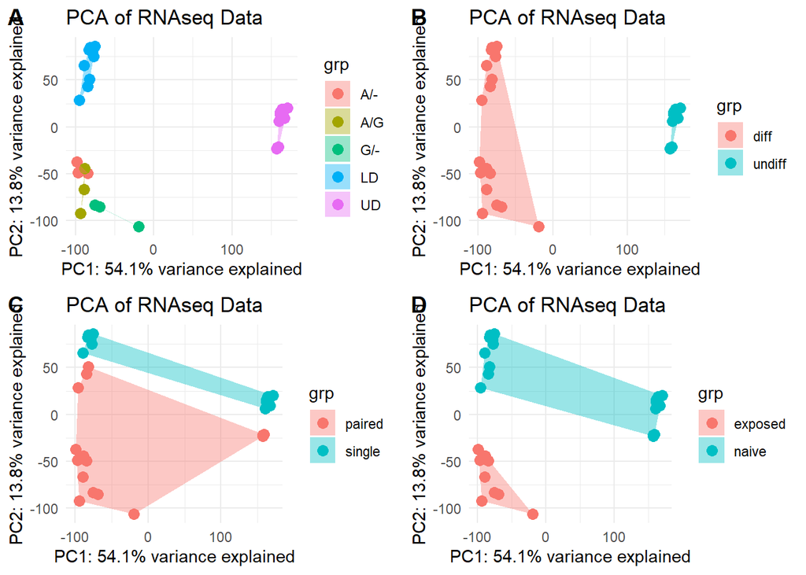

```r
e <- pca.fig(pData, 'PC1', 'PC2', pData$diff)
f <- pca.fig(pData, 'PC1', 'PC2', pData$ends)
g <- pca.fig(pData, 'PC1', 'PC2', pData$crispr)

plot_grid(a, e,f,g, labels = "AUTO", nrow = 2, ncol = 2)
```

Looking at a single dimension at a time, it appears that dimension 1 and 2 explain differentiated status and exposure to CRISPR respectively. The third dimension seems to be the one that really separates my lesion clones.

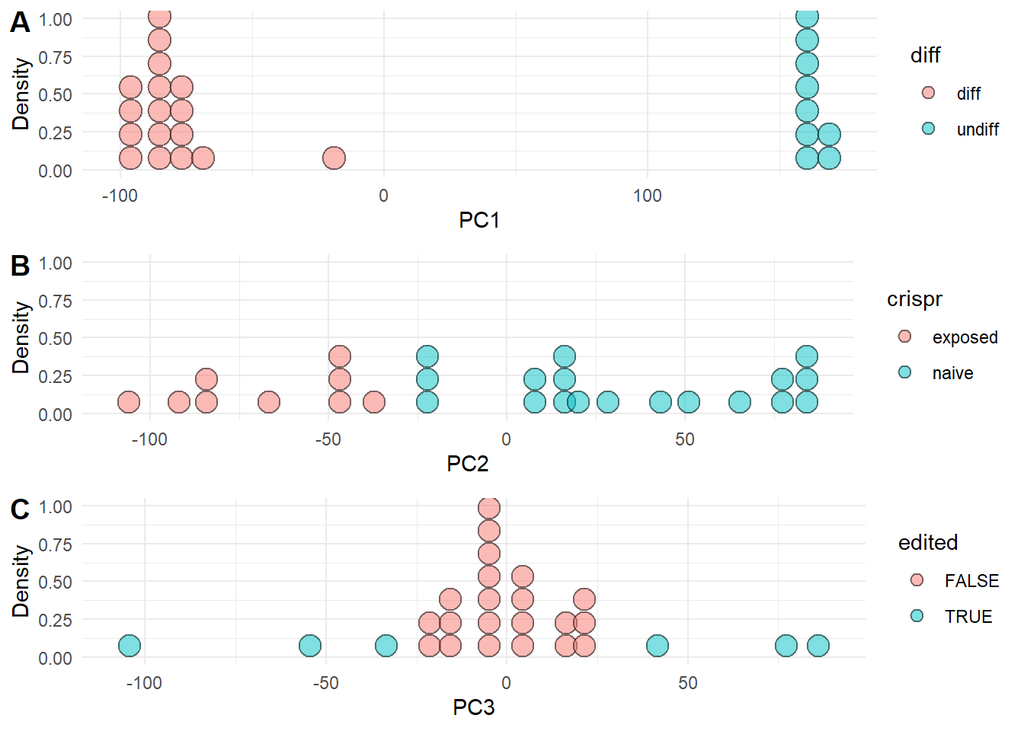

```r
den1<-ggplot() +
  geom_dotplot(data=pData, aes(x=PC1, group=diff, fill=diff),alpha=0.5) +
  xlab("PC1") +
  ylab("Density") +
  theme_minimal()
den2<-ggplot() +
  geom_dotplot(data=pData, aes(x=PC2, group=crispr, fill=crispr),alpha=0.5) +
  xlab("PC2") +
  ylab("Density") +
  theme_minimal()
den3<-ggplot() +
  geom_dotplot(data=pData, aes(x=PC3, group=edited, fill=edited),alpha=0.5) +
  xlab("PC3") +
  ylab("Density") +
  theme_minimal()

plot_grid(den1, den2, den3, labels = "AUTO", ncol = 1, scale = 1)
```

## Heatmap

Now we have everything we need to generate a simple heatmap. Initially I will use this simple package to generate a heatmap of the 500 most variable genes. The problem here is that the most variable genes by far are differentially expressed between the differentiated versus undifferentiated samples, so we need to exclude undifferentiaed samples if we want to get a better idea of what makes my lesion-clones unique.

[figure not shown]

```r
var_genes <- apply(logcounts, 1, var) # Store the variance of each gene in the object var_gene

select_var <- names(sort(var_genes, decreasing=TRUE))[1:500] # Grab only the 500 most variable genes. Could be any number
highly_variable_lcpm <- logcounts[select_var,] # Filter the data for those 500 genes

# Pull in a color palette
mypalette <- brewer.pal(11,"RdYlBu")
morecols <- colorRampPalette(mypalette)

# Plot the heatmap
heatmap.2(highly_variable_lcpm,col=rev(morecols(50)),trace="none", main="Top 500 most variable genes across samples",scale="row")
```

## Combine gene data and count data

```r
expr_data <- data.frame(cpm(my_dge, log=T)) %>%
  rownames_to_column(var="genes") %>%
  dplyr::left_join(data.frame(my_dge$genes), by="genes") %>%
  dplyr::select(genes,Symbol,everything())

colnames(expr_data) <- gsub("X.", "", colnames(expr_data)) # Remove the "X." prefix from sample names

write.csv(data.frame(expr_data), './cpm_data.csv') ### Save here as a checkpoint
write.csv(data.frame(highly_variable_lcpm), './500_genes.csv')
```

## Z-score

Now that I have my data in counts per million, we normalize the genes using a z-score calculation. This calculation takes the observed value, subtracts the average value for each gene, and then divides by the standard deviation per gene to give you a value of deviance from the norm.I am confident that there’s a much easier way to do this, but this is how I did it.

```r
zdata <- expr_data   ### Don't work on the primary data set
zdata$avg <- rowMeans(expr_data[,3:29]) ### Add a column for row averages
zdata$sd <- apply(expr_data[,3:29],1,sd) ### Add a column for row standard deviations
zdata1 <- cbind(zdata[,1:2], ((zdata[,3:29]-zdata[,30])/zdata[,31])) ### Make a new data frame with the gene ID/symbol and Z-scores (observed - average / sd).

### FOR T-TEST P-VALUES
# First, create the function to do t-tests between groups and pull out the p-value
ttestdata <-function(zdata1, grp1, grp2) {
  x= zdata1[grp1]
  y= zdata1[grp2]
  x= as.numeric(x)
  y= as.numeric(y)
  results= t.test(x,y)
  results$p.value
}

# apply the function pairwise between each group. Later we will do this same thing but for Fold-change
pval_A_vs_G   <- (apply(zdata1,1,ttestdata, grp1 = c(3:5),   grp2= c(6:8)))
pval_AG_vs_A  <- (apply(zdata1,1,ttestdata, grp1 = c(9:11),  grp2= c(3:5)))
pval_A_vs_LD  <- (apply(zdata1,1,ttestdata, grp1 = c(3:5),   grp2= c(12:21)))
pval_A_vs_UD  <- (apply(zdata1,1,ttestdata, grp1 = c(3:5),   grp2= c(22:29)))
pval_AG_vs_G  <- (apply(zdata1,1,ttestdata, grp1 = c(9:11),  grp2= c(6:8)))
pval_G_vs_LD  <- (apply(zdata1,1,ttestdata, grp1 = c(6:8),   grp2= c(12:21)))
pval_G_vs_UD  <- (apply(zdata1,1,ttestdata, grp1 = c(6:8),   grp2= c(22:29)))
pval_AG_vs_LD <- (apply(zdata1,1,ttestdata, grp1 = c(9:11),  grp2= c(12:21)))
pval_AG_vs_UD <- (apply(zdata1,1,ttestdata, grp1 = c(9:11),  grp2= c(22:29)))
pval_LD_vs_UD <- (apply(zdata1,1,ttestdata, grp1 = c(12:21), grp2= c(22:29)))

###### FOR FOLD-CHANGE ANALYSIS
# Find mean for each group
A_ = apply(zdata1[,3:5],1,mean)
G_ = apply(zdata1[,6:8],1,mean)
AG = apply(zdata1[,9:11],1,mean)
LD = apply(zdata1[,12:21],1,mean)
UD = apply(zdata1[,22:29],1,mean)

#Since we've already log transformed our data, we can find fold-change by taking the difference between groups
logFC_A_vs_G   <- (A_ - G_)
logFC_AG_vs_A  <- (AG - A_)
logFC_A_vs_LD  <- (A_ - LD)
logFC_A_vs_UD  <- (A_ - UD)
logFC_AG_vs_G  <- (AG - G_)
logFC_G_vs_LD  <- (G_ - LD)
logFC_G_vs_UD  <- (A_ - UD)
logFC_AG_vs_LD <- (AG - LD)
logFC_AG_vs_UD <- (AG - UD)
logFC_LD_vs_UD <- (LD - UD)


### Now bind all of our data into one big table
compData <- cbind(zdata1, pval_A_vs_G, logFC_A_vs_G, pval_A_vs_LD, logFC_A_vs_LD, pval_A_vs_UD, logFC_A_vs_UD, pval_AG_vs_A, logFC_AG_vs_A, pval_AG_vs_G, logFC_AG_vs_G, pval_AG_vs_LD, logFC_AG_vs_LD, pval_AG_vs_UD, logFC_AG_vs_UD, pval_G_vs_LD, logFC_G_vs_LD, pval_G_vs_UD, logFC_G_vs_UD, pval_LD_vs_UD, logFC_LD_vs_UD)

write.csv(data.frame(compData), './20210421_comparison_data.csv') ### Save here as a checkpoint
```

## Volcano plots

I use volcano plots to display differentially expressed genes between groups. I found a package to make enhanced volcano plots so I tested it out with the A/- versus G/- comparison below.

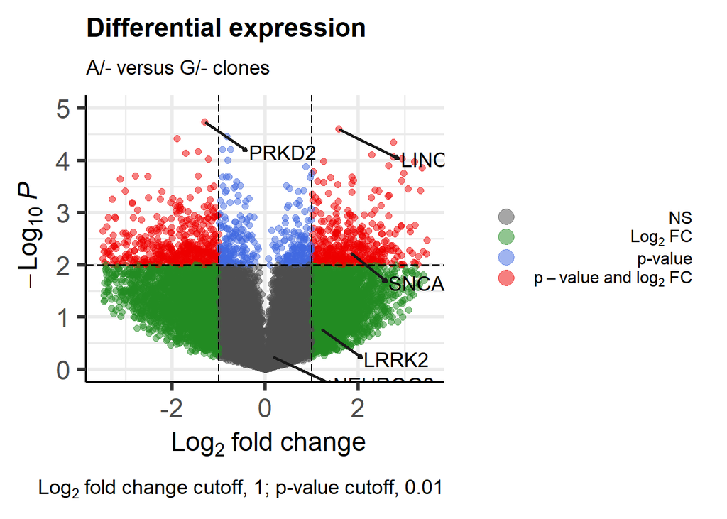

```r
EnhancedVolcano(compData,
                lab= compData$Symbol,
                x= 'logFC_A_vs_G',
                y= 'pval_A_vs_G',
                pCutoff = 0.01,
                FCcutoff = 1,
                selectLab = c("SNCA", "LRRK2", "NEUROG2", "PRKD2", "LINC02003"),
                colAlpha = 0.5,
                ylim = c(0,5),
                xlim = c(-3.5,3.5),
                legendPosition = "right",
                legendLabSize = 12,
                #colGradient = c('red','royalBlue'),
                drawConnectors = T,
                widthConnectors = 1,
                boxedLabels = F,
                subtitle = "A/- versus G/- clones",
                title = "Differential expression",
                caption = bquote(~Log[2]~ "fold change cutoff, 1; p-value cutoff, 0.01"),
                )
```

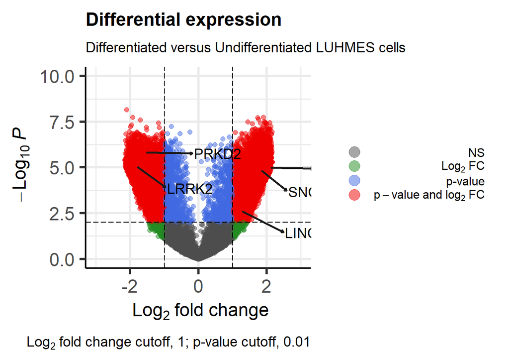

```r
EnhancedVolcano(compData,
                lab= compData$Symbol,
                x= 'logFC_LD_vs_UD',
                y= 'pval_LD_vs_UD',
                pCutoff = 0.01,
                FCcutoff = 1,
                selectLab = c("SNCA", "LRRK2", "NEUROG2", "PRKD2", "LINC02003"),
                colAlpha = 0.5,
                ylim = c(0,10),
                xlim = c(-3,3),
                legendPosition = "right",
                legendLabSize = 12,
                #colGradient = c('red','royalBlue'),
                drawConnectors = T,
                widthConnectors = 1,
                boxedLabels = F,
                subtitle = "Differentiated versus Undifferentiated LUHMES cells",
                title = "Differential expression",
                caption = bquote(~Log[2]~ "fold change cutoff, 1; p-value cutoff, 0.01"),
                )
```